# R Notebook

## biplots PCA

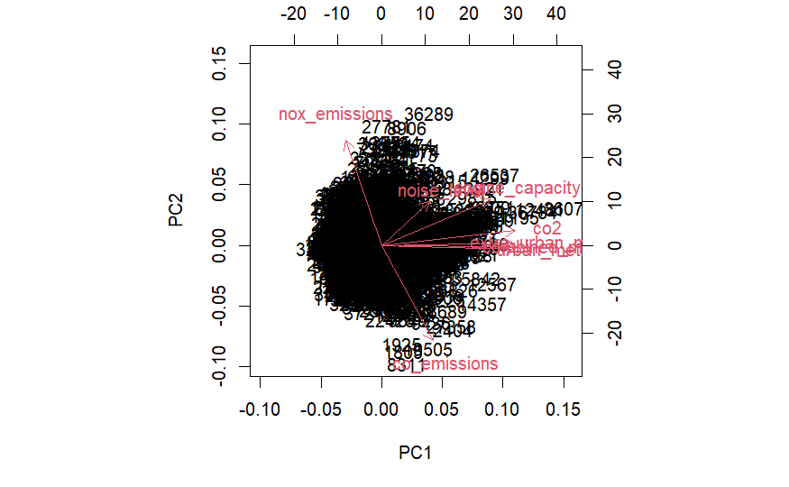

```r
biplot(Xtrain.pca.scaled,c(1,2))
```

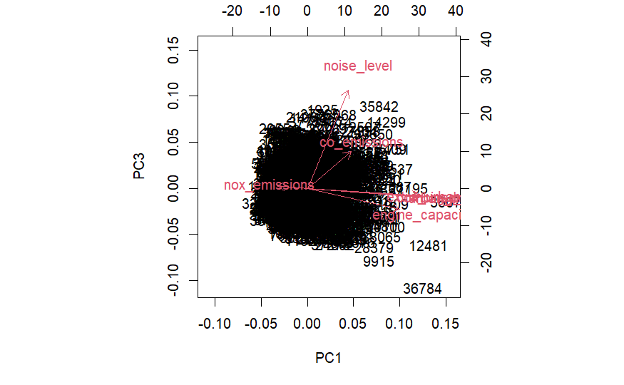

```r
biplot(Xtrain.pca.scaled,c(1,3))
```

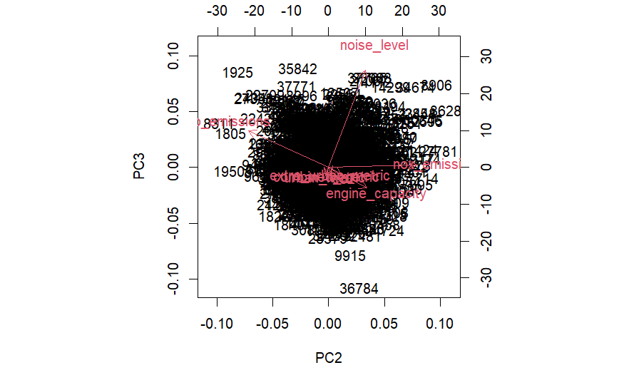

```r
biplot(Xtrain.pca.scaled,c(2,3))
```

The biplots aren’t very clear and we can’t recognize any categorical variables in them. Let’s plot them again.

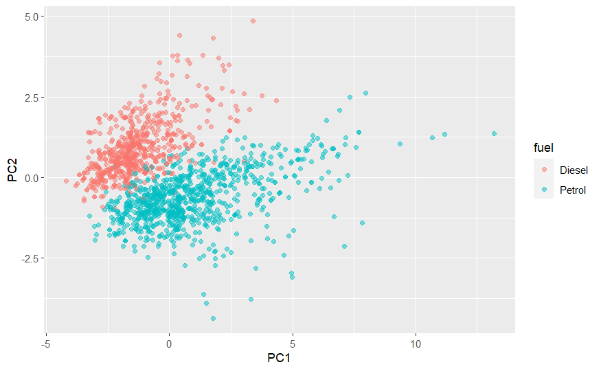

```r
# plotting scores
score_plot <- data.frame(Xtrain.pca.scaled$scores)
score_plot$fuel <-Xtrain[,"fuel_type"]
score_plot$type <-Xtrain[,"transmission_type"]
score_plot$euro <-Xtrain[,"euro_standard"]
score_plot$combined <- interaction(score_plot$fuel,score_plot$type)
ggplot(score_plot ,aes(PC1,PC2, color = fuel)) + geom_point(alpha = 0.5)
```

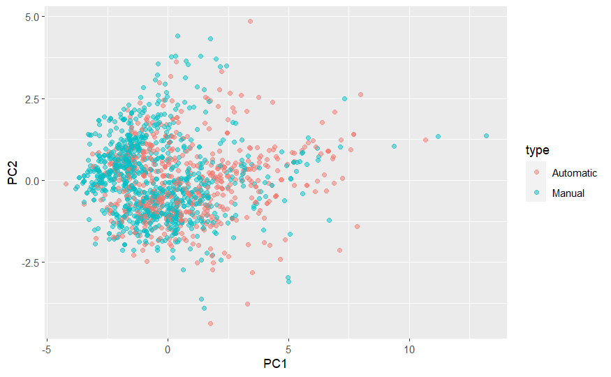

```r
ggplot(score_plot ,aes(PC1,PC2, color = type)) + geom_point(alpha = 0.5)
```

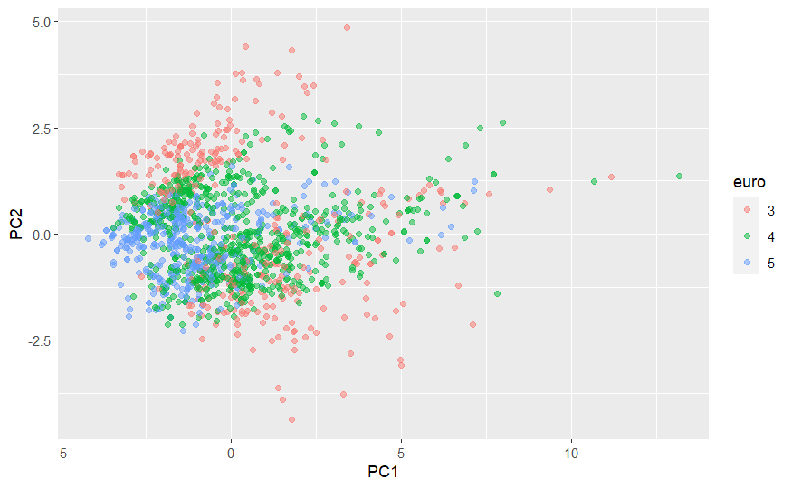

```r
ggplot(score_plot ,aes(PC1,PC2, color = euro)) + geom_point(alpha = 0.5)
```

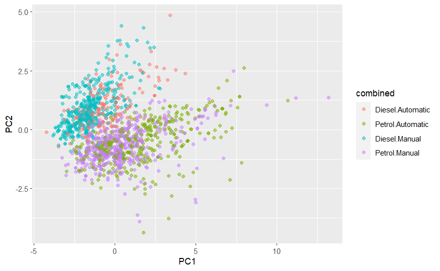

```r
ggplot(score_plot ,aes(PC1,PC2, color = combined)) + geom_point(alpha = 0.5)
```

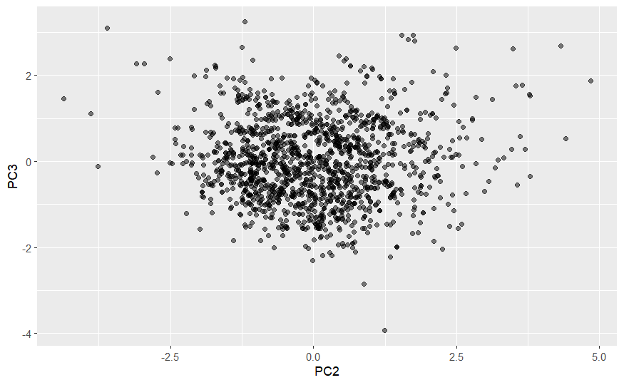

```r
ggplot(score_plot ,aes(PC2,PC3)) + geom_point(alpha = 0.5)
```

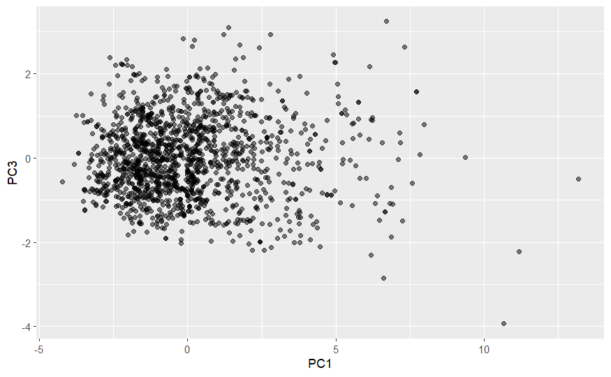

```r
ggplot(score_plot ,aes(PC1,PC3)) + geom_point(alpha = 0.5)
```

We could only recognieze the fuel type out of the principal components.

## Compare to robust PCA

So we do robust PCA with PcaHubert

```r
Xtrain.robpca <-PcaHubert(Xtrain[,continousCols], k=3,scale= mad,crit.pca.distances=0.99)
summary(Xtrain.robpca)
```

```
Call:
PcaHubert(x = Xtrain[, continousCols], k = 3, scale = mad, crit.pca.distances = 0.99)
Importance of components:
                          PC1    PC2    PC3
Standard deviation     2.3202 1.4146 1.0879
Proportion of Variance 0.5553 0.2064 0.1221
Cumulative Proportion  0.5553 0.7617 0.8838
```

```r
Xtrain.robpca$loadings
```

```
                          PC1         PC2         PC3
engine_capacity    -0.3195506 -0.51086403  0.06520871
urban_metric       -0.4595804 -0.07100224  0.07352439
extra_urban_metric -0.3924848 -0.05472938  0.09417052
combined_metric    -0.4163030 -0.06024124  0.07944701
co2                -0.4234058 -0.16231766  0.09312102
noise_level        -0.1338704 -0.14187366 -0.97662779
co_emissions       -0.2267574  0.53815975 -0.10973282
nox_emissions       0.3327282 -0.62550878  0.02544445
```

Looks very similar to not robust PCA maybe the loading of nox emissions is a little bit of.

Now we’re going to use robust PCA to check for PCA outliers:

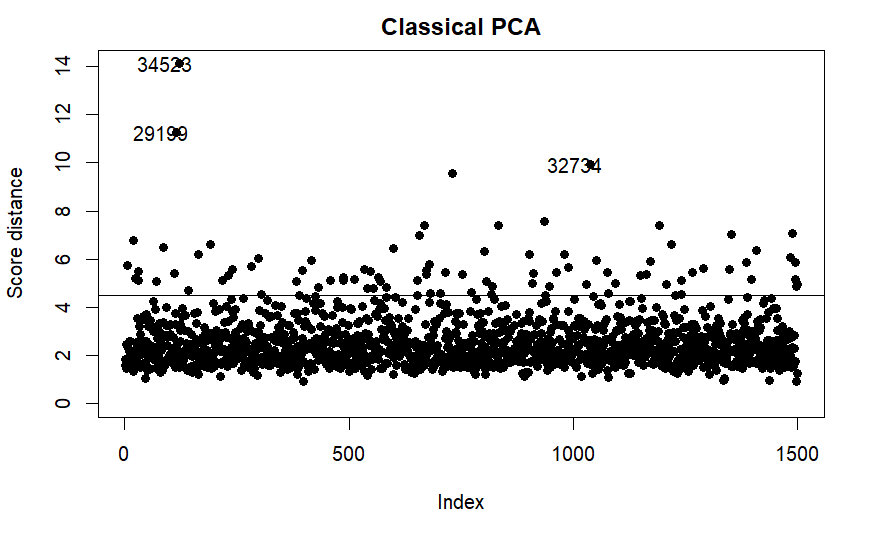

```r
plot(Xtrain.pca.scaled,pch=19)
```

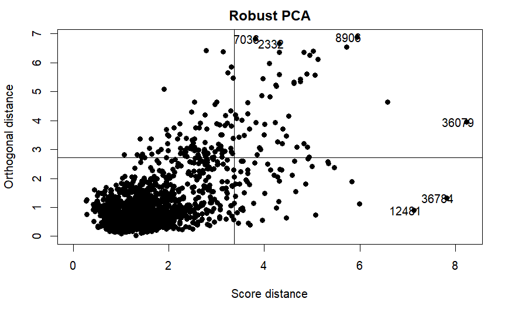

```r
plot(Xtrain.robpca,pch=19)
```

```r
bad_leverage_points <- c("7036","2332","8906","36079")
good_leverage_points <- c("12481","36784")
print(subset.trans[bad_leverage_points,])
```

|  | manufacturer | model | description | euro_standard | transmission_type | engine_capacity | fuel_type | urban_metric | extra_urban_metric | combined_metric | noise_level | co2 | co_emissions | nox_emissions |
| --- | --- | --- | --- | --- | --- | --- | --- | --- | --- | --- | --- | --- | --- | --- |
| 7036 | SsangYong | Rexton | 270 SX Manual | 3 | Manual | 2696 | Diesel | 10.9 | 7.7 | 8.9 | 3.032345 | 237 | 780 | 580 |
| 2332 | Renault | Espace | 1.9 dCi (JK0GB6) (w/sunroof) | 3 | Manual | 1870 | Diesel | 8.9 | 6.0 | 7.0 | 1.587600 | 187 | 337 | 694 |
| 8906 | Land Rover | Discovery Series II | 2.5 TD5 (2002 Model Year) | 3 | Manual | 2495 | Diesel | 11.5 | 8.2 | 9.4 | 4.001504 | 262 | 300 | 700 |
| 36079 | Dodge | SRT10 | Cabriolet | 4 | Manual | 8285 | Petrol | 34.5 | 13.2 | 21.1 | 3.175797 | 488 | 796 | 9 |

```r
print(subset.trans[good_leverage_points,])
```

|  | manufacturer | model | description | euro_standard | transmission_type | engine_capacity | fuel_type | urban_metric | extra_urban_metric | combined_metric | noise_level | co2 | co_emissions | nox_emissions |
| --- | --- | --- | --- | --- | --- | --- | --- | --- | --- | --- | --- | --- | --- | --- |
| 12481 | Ferrari | All Models | 612 Scaglietti | 3 | Manual | 5748 | Petrol | 32.1 | 14.0 | 20.7 | 1.9546751 | 475 | 306 | 32 |
| 36784 | Bentley Motors | Brooklands | CoupÃ© | 4 | Automatic | 6761 | Petrol | 28.8 | 14.1 | 19.5 | 0.7936508 | 465 | 294 | 31 |

There are a lot of bad leverage points so we choose to continue with the robust PCA.

## scores of validation set

```r
Xval.robpca.scaled <- scale(Xval[,continousCols],center = Xtrain.robpca$center, scale= Xtrain.robpca$scale)
Xval.robpca.scores <- Xval.robpca.scaled %*% Xtrain.robpca$loadings
Xval.robpca.pred <- t(t(Xval.robpca.scores%*%t(Xtrain.robpca$loadings)) + Xtrain.robpca$center/Xtrain.robpca$scale)

Xtrain.robpca.scaled <- scale(Xtrain[,continousCols],center = Xtrain.robpca$center, scale= Xtrain.robpca$scale)
Xtrain.robpca.scores <- Xtrain.robpca.scaled %*% Xtrain.robpca$loadings
Xtrain.robpca.pred <- t(t(Xtrain.robpca.scores%*%t(Xtrain.robpca$loadings)) + Xtrain.robpca$center/Xtrain.robpca$scale)
```

## outlier map validation set

To make an outlier map we need the orthogonal and score distances.

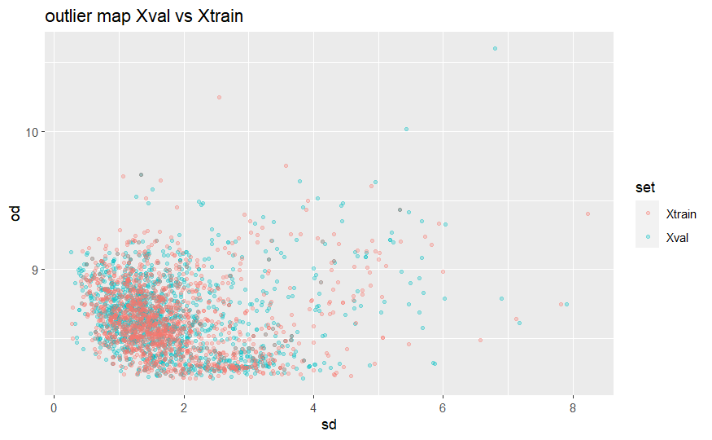

```r
euclnorm <- function(y) sqrt(sum(y^2))
Xval.robpca.od <- apply(Xval.robpca.scaled - Xval.robpca.pred, 1, euclnorm)
Xval.robpca.sd <- sqrt(mahalanobis(Xval.robpca.scores, center = 0, diag(Xtrain.robpca$eigenvalues)))

Xtrain.robpca.od <- apply(Xtrain.robpca.scaled - Xtrain.robpca.pred, 1, euclnorm)
Xtrain.robpca.sd <- sqrt(mahalanobis(Xtrain.robpca.scores, center = 0, diag(Xtrain.robpca$eigenvalues)))

outlier_map <- data.frame(
  c(Xval.robpca.od,Xtrain.robpca.od),
  c(Xval.robpca.sd,Xtrain.robpca.sd),
  c(rep("Xval", 1500), rep("Xtrain",1500)))
names(outlier_map) <- c("od","sd","set")
ggplot(outlier_map,aes(sd,od, color = set)) +
  geom_point(alpha = 0.3, size = 1)+
  ggtitle("outlier map Xval vs Xtrain")
```

This outlier map isn’t the same as from the robust PCA. As you can see the distribution of the Xval is barely different from the Xtrain on the outlier map this validates the robust PCA.

# Clustering

## partitioning cluster analysis

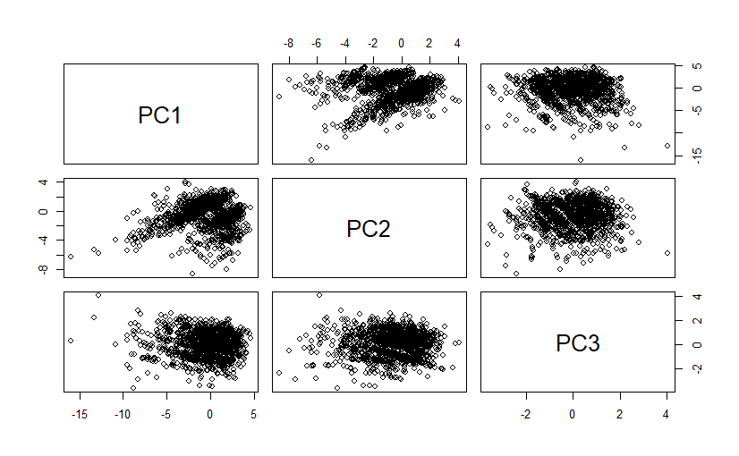

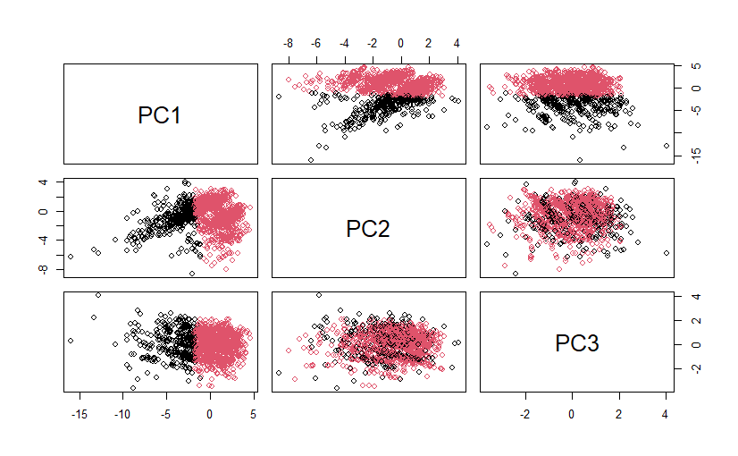

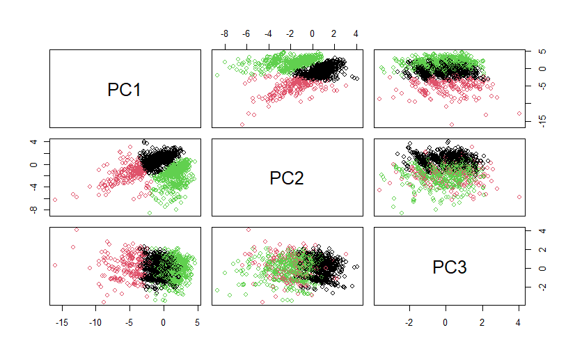

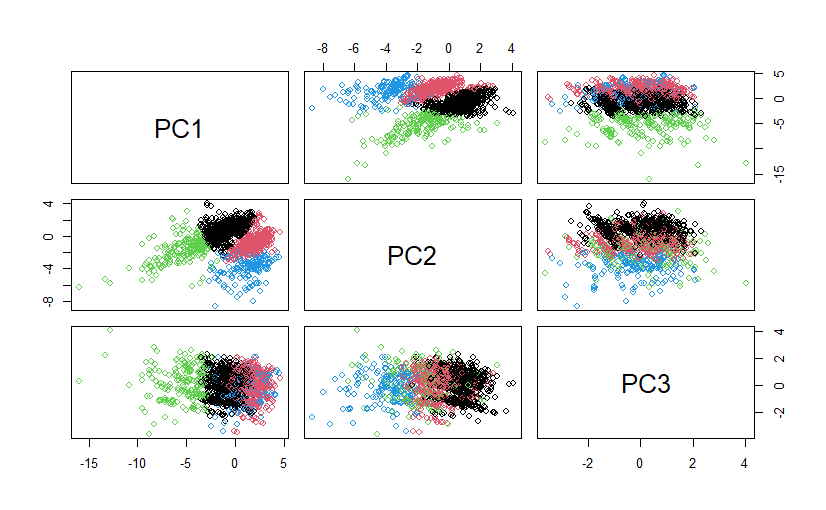

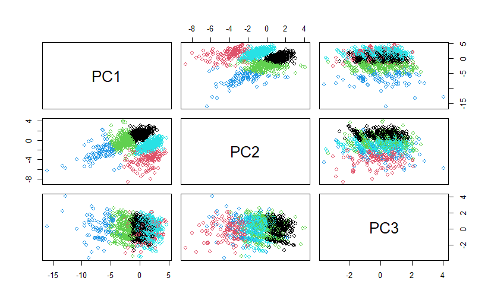

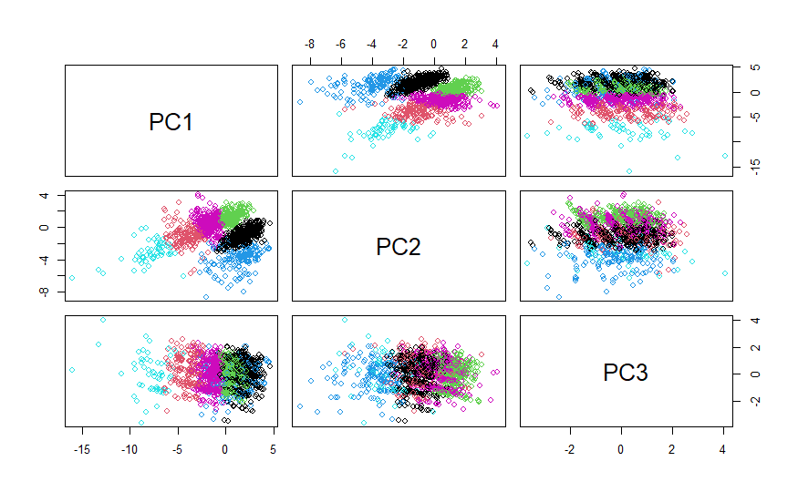

```r
for (amount_centers in 1:6) {
  Xtrain.kmeans <-kmeans(Xtrain.robpca.scaled, amount_centers)
  pairs(Xtrain.robpca.scores, col=Xtrain.kmeans$cluster)
}
```

### pam

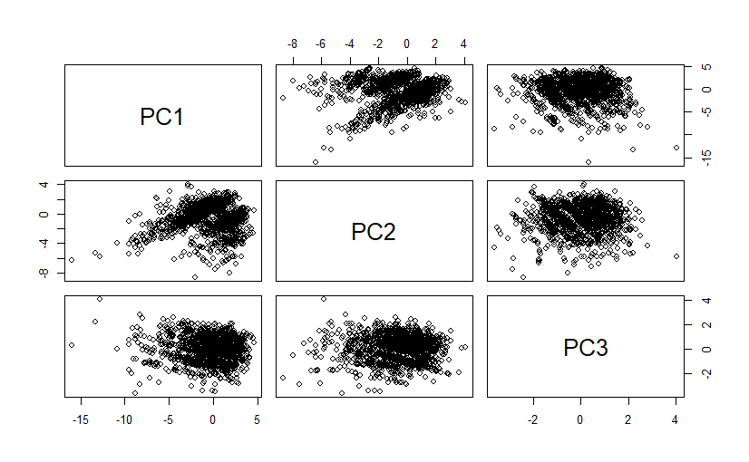

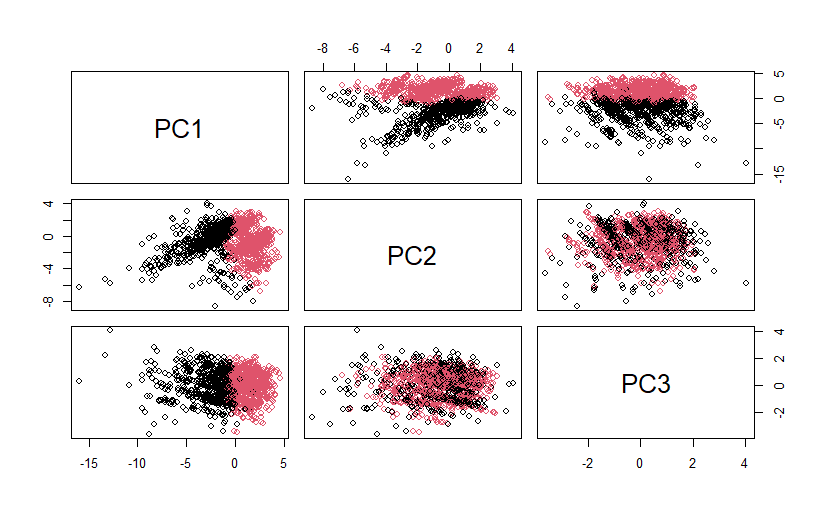

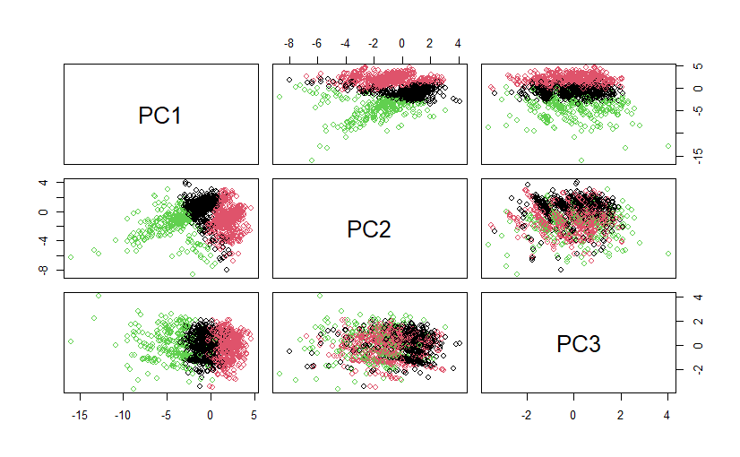

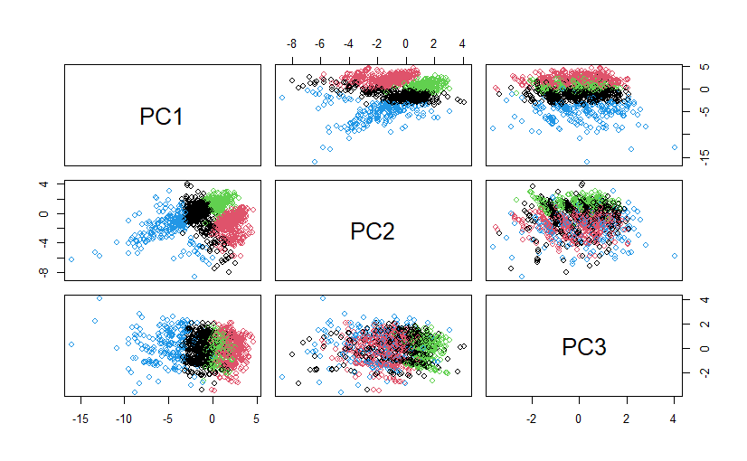

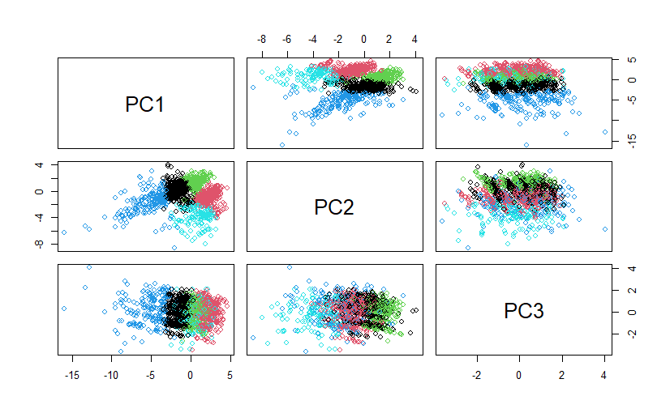

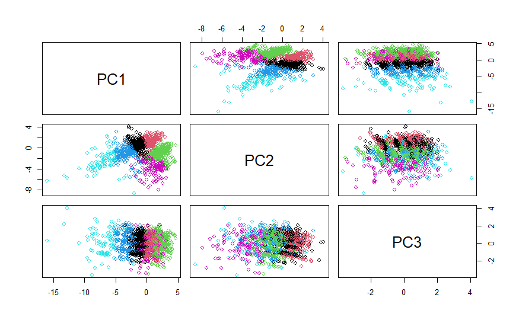

```r
for (amount_centers in 1:6) {
  Xtrain.pam <-pam(Xtrain.robpca.scaled, k = amount_centers, metric="manhattan")
  pairs(Xtrain.robpca.scores, col=Xtrain.pam$clustering)
}
```

### conclusion

The only categorical variable you can recognize on the score plot was fuel the other if you would plot them are overlapping ruling them out. Meaning neither pam or kmeans recogized any categorical variables.

We would go with 1 cluster here.

## hierarchical clustering observations

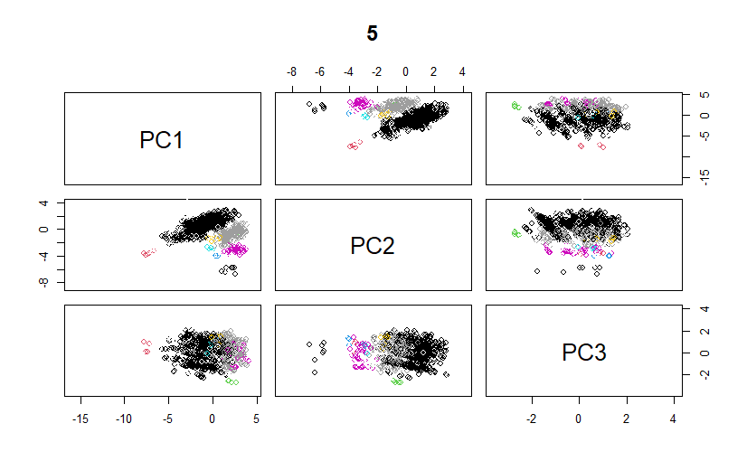

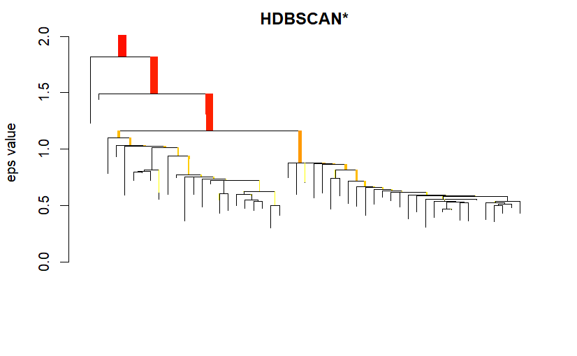

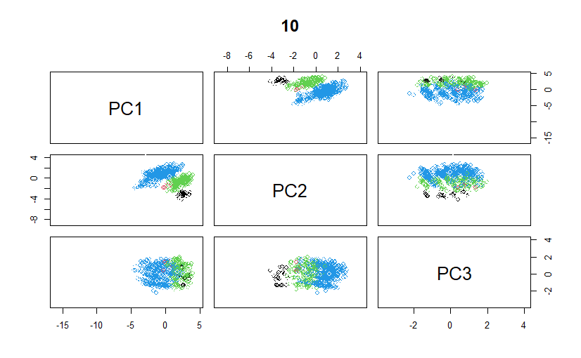

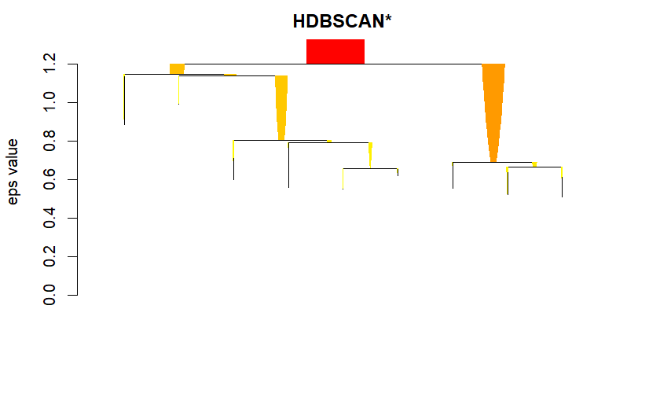

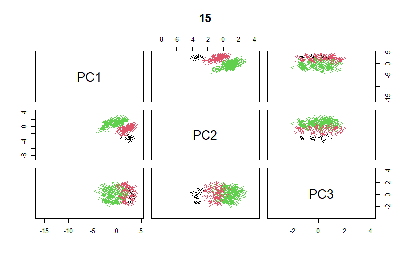

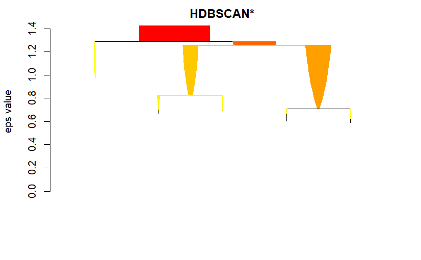

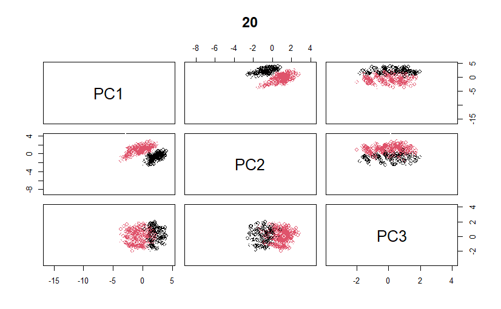

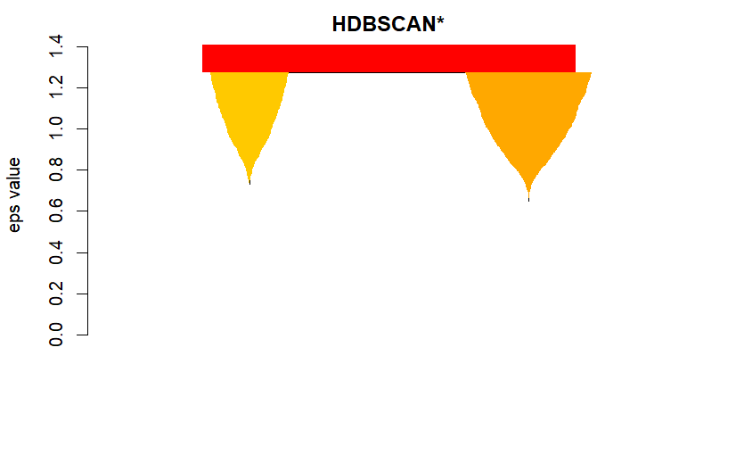

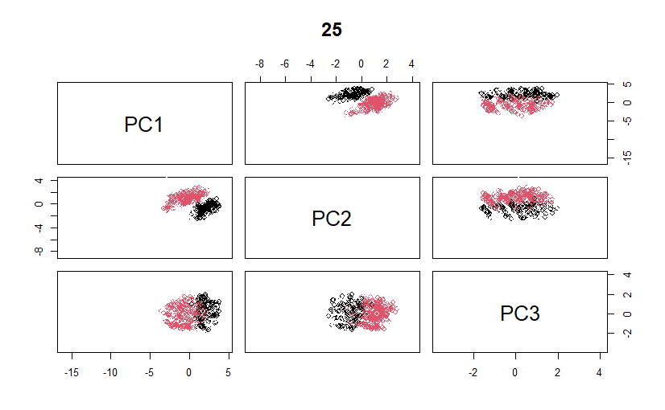

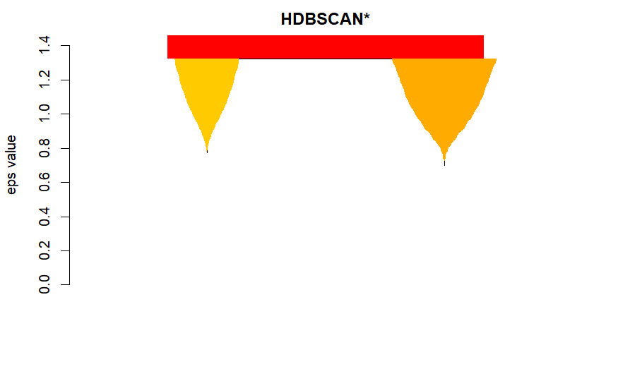

```r
for (pts in c(5,10,15,20,25)) {
  Xtrain.hdbscan <- hdbscan(Xtrain.robpca.scaled,minPts = pts)
  pairs(Xtrain.robpca.scores, col=Xtrain.hdbscan$cluster, main =pts)
  plot(Xtrain.hdbscan)
}
```

### hclust

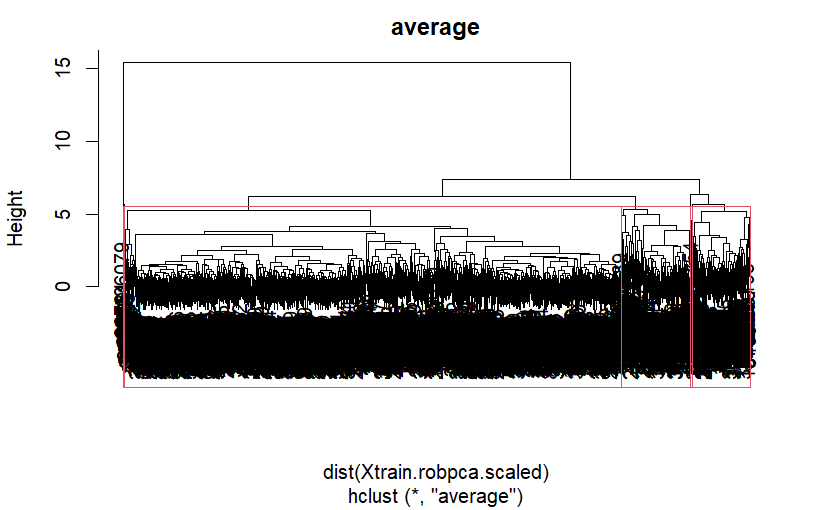

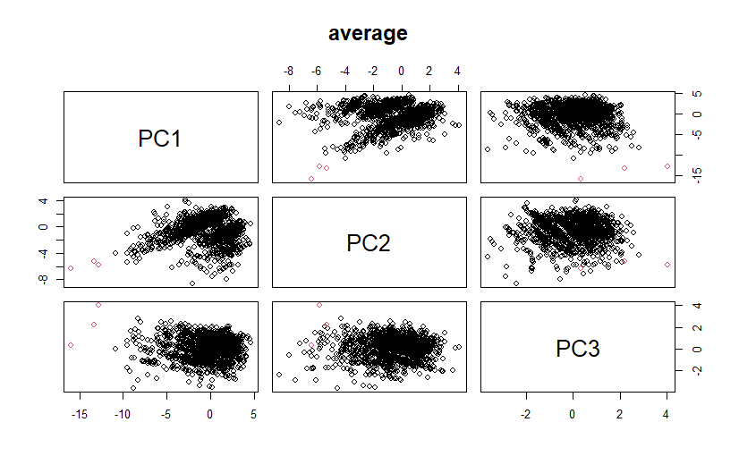

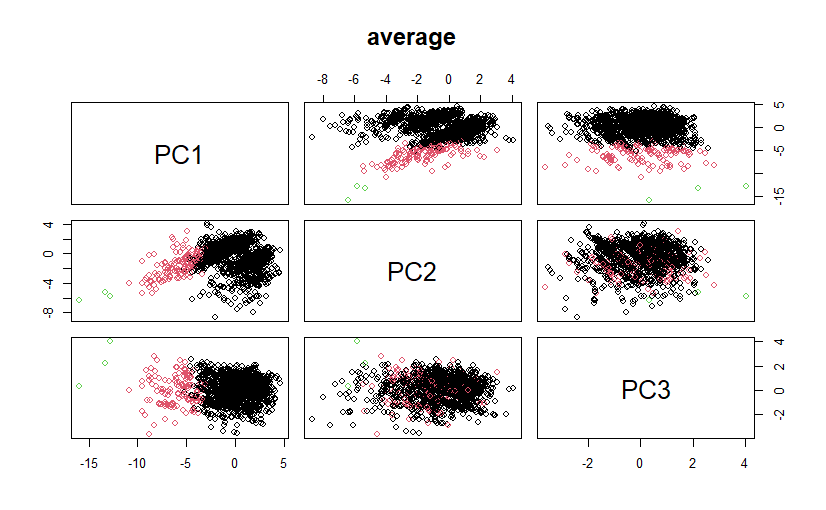

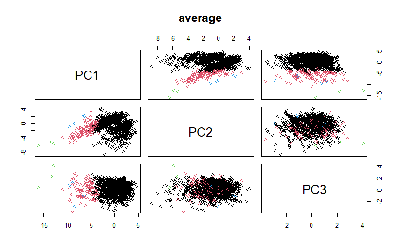

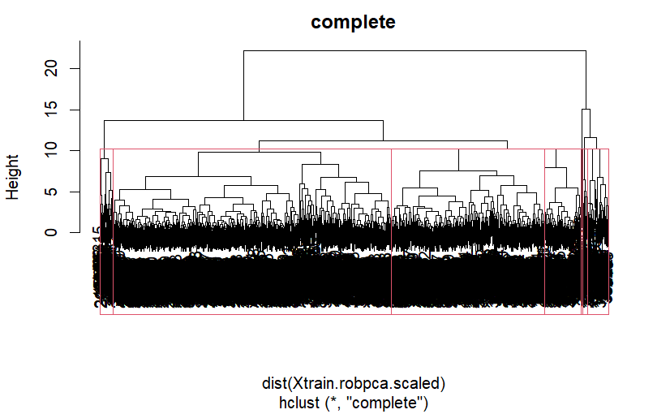

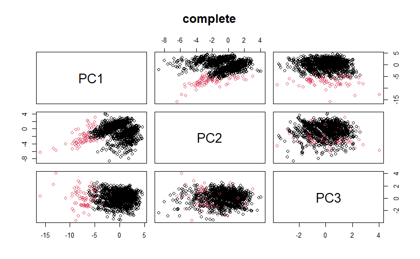

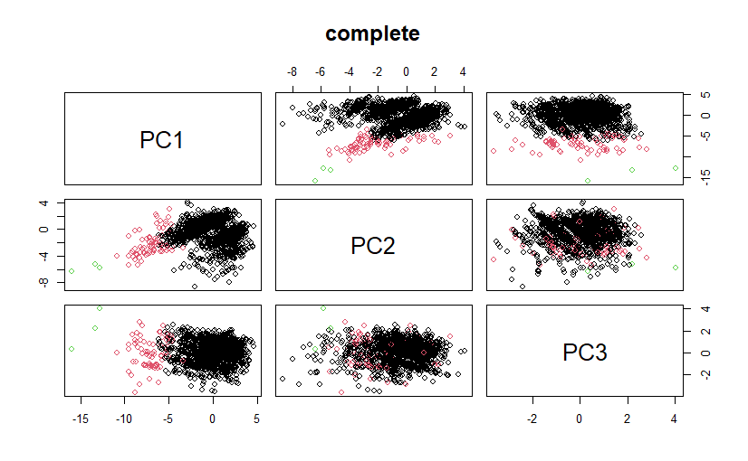

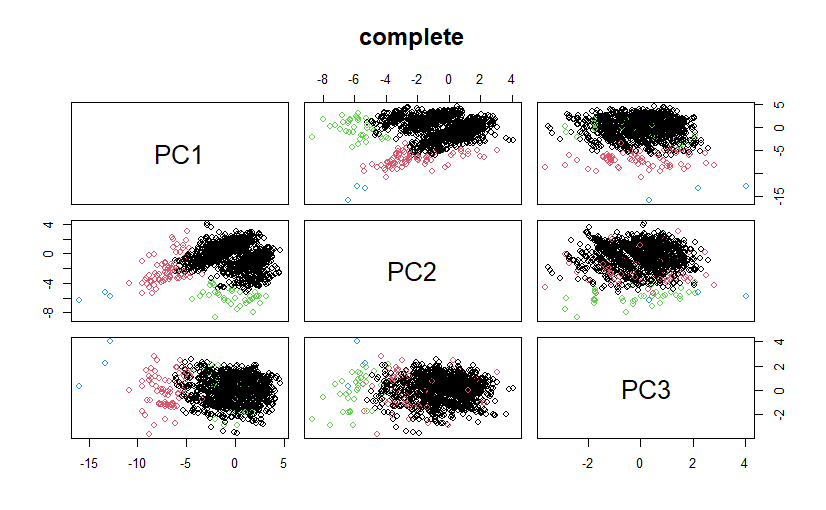

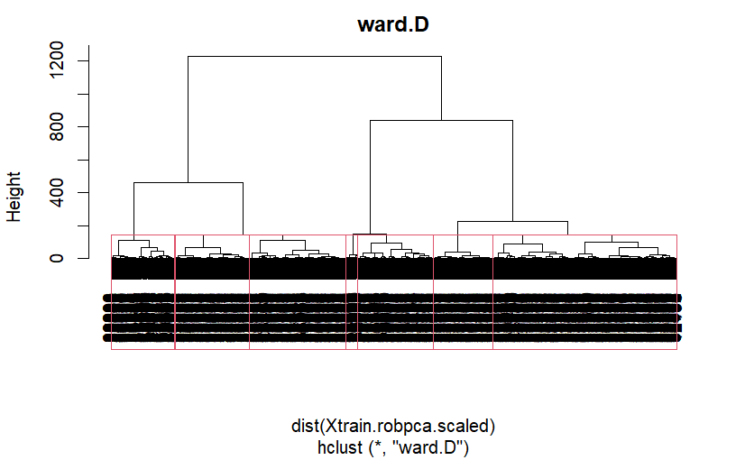

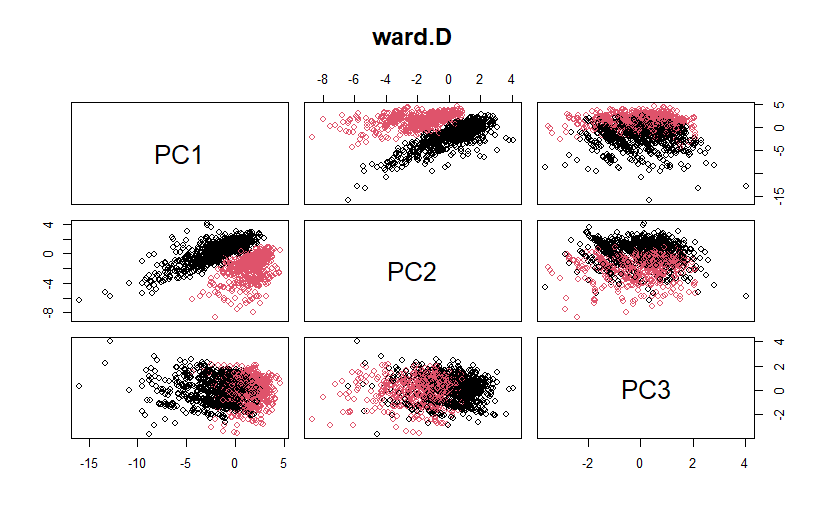

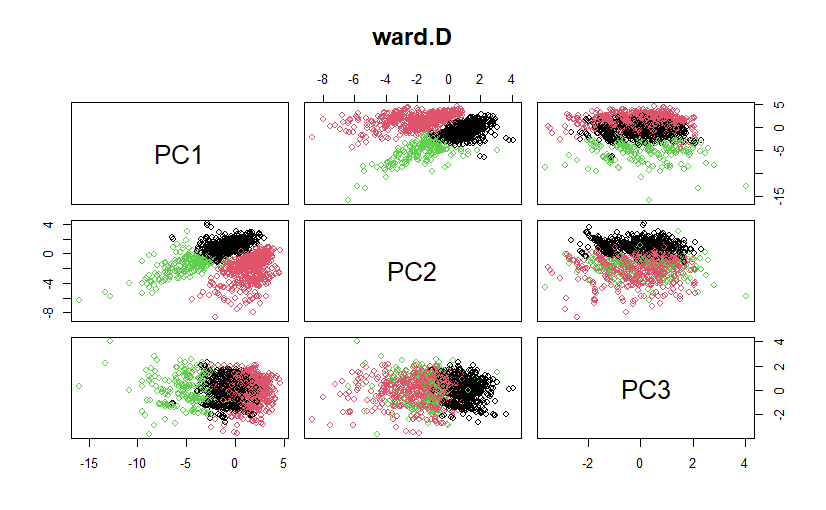

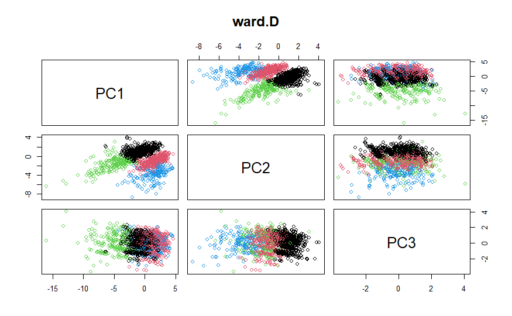

```r
for (mt in c("average","complete","ward.D")) {
  Xtrain.hclust <- hclust(dist(Xtrain.robpca.scaled),method =mt)
  plot(Xtrain.hclust, main = mt)
  rect.hclust(Xtrain.hclust, k = 7)
  for (amount_cluster in c(2,3,4)){
  pairs(Xtrain.robpca.scores, col=cutree(Xtrain.hclust,k=amount_cluster), main = mt)
  }
}
```

## hierarchical clustering variables

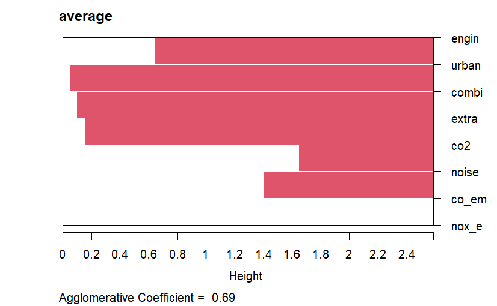

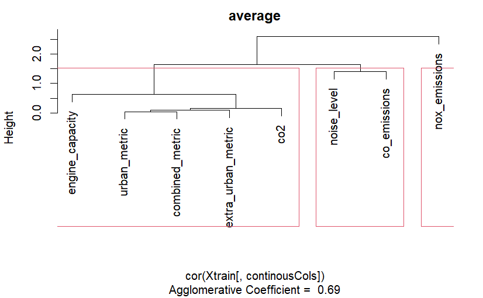

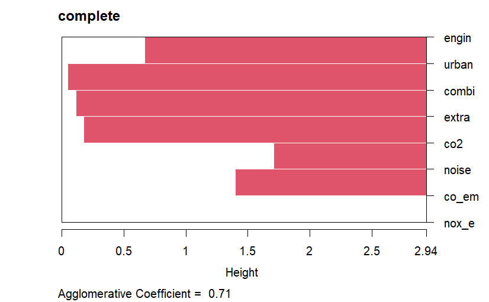

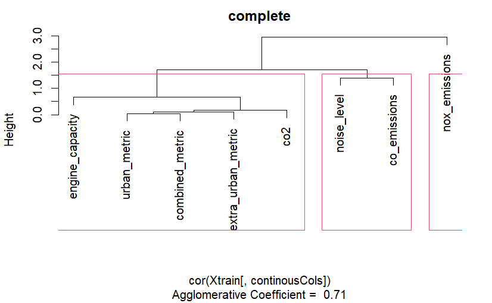

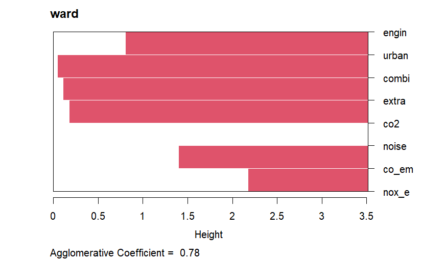

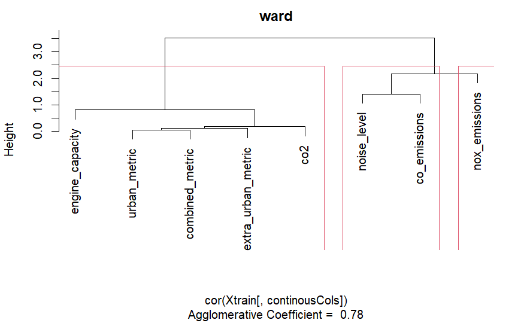

```r
for (mt in c("average","complete","ward")) {
  Xtrain.var.agnes <- agnes(cor(Xtrain[,continousCols]), method = mt)
  plot(Xtrain.var.agnes, main = mt)
  rect.hclust(Xtrain.var.agnes, k = 3)
}
```

## clustering that corresponds to fuel

Hclust with ward found clustering that correspond with fuel type.

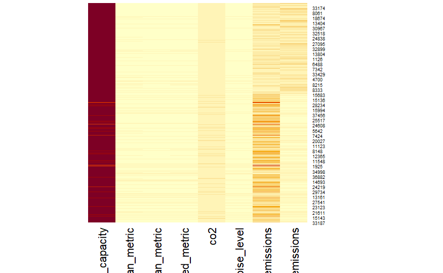

```r
#Xtrain.hclust.ward.dendo <-as.dendrogram(hclust(dist(Xtrain.robpca.scaled), method = "ward.D"))
#Xtrain.var.agnes.ward.dendo <- as.dendrogram(agnes(cor(Xtrain[,continousCols]), method = "ward"))

Xtrain.hclust.ward <-cutree(hclust(dist(Xtrain.robpca.scaled), method = "ward.D"), k = 2)
Xtrain.var.agnes.ward <- cutree(agnes(cor(Xtrain[,continousCols]), method = "ward"),k=3)

Xtrain.sort_cluster <- Xtrain[,continousCols][order(Xtrain.hclust.ward),order(Xtrain.var.agnes.ward)]
Xtrain.sort_cluster.scaled <- Xtrain.robpca.scaled[order(Xtrain.hclust.ward),order(Xtrain.var.agnes.ward)]
#Xtrain.sort_cluster.melt <- melt(Xtrain.sort_cluster)
#Xtrain.sort_cluster.melt$idu <- as.numeric(row.names(Xtrain.sort_cluster.melt))
#ggplot(Xtrain.sort_cluster.melt,aes(variable,y =idu, fill = value))+geom_tile()

heatmap(data.matrix(Xtrain.sort_cluster),Rowv = NA,Colv = NA )
```

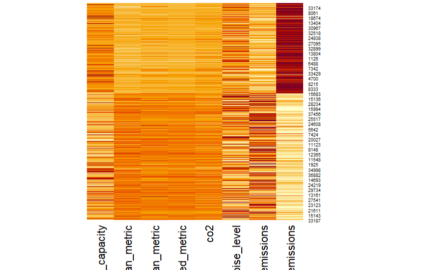

```r
heatmap(data.matrix(Xtrain.sort_cluster.scaled),Rowv = NA,Colv = NA)
```

On the heatmap you can clearly see the conditional distribution on fuel and they are similar for similar variables.

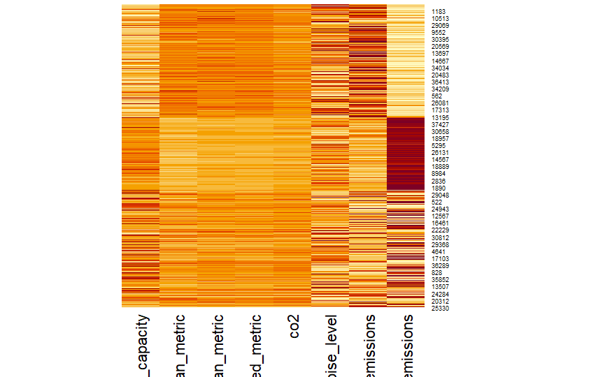

```r
Xtrain.hdbscan.15 <-hdbscan(Xtrain.robpca.scaled,minPts = 15)
Xtrain.sort_cluster.scaled.hdbscan <- Xtrain.robpca.scaled[order(Xtrain.hdbscan.15$cluster),order(Xtrain.var.agnes.ward)]
heatmap(data.matrix(Xtrain.sort_cluster.scaled.hdbscan),Rowv = NA,Colv = NA)
```

# Linear regression

## assumptions linear model

## ANOVA

## metrics

## confidence interval

# Classification

## LDA and QDA

## knn

## preffered model